# Credit Card Fraud Detection

### Dataset Used: [Credit Card Transactions Dataset](https://www.kaggle.com/datasets/priyamchoksi/credit-card-transactions-dataset/data)

## 1. Import required libraries

```python
# Ignore warnings
import warnings
warnings.filterwarnings("ignore")
```

```python
# Import libraries for data manipulation
import numpy as np
import pandas as pd

# Import visualization libraries
import matplotlib.pyplot as plt
import seaborn as sns

# Import data preprocessing libraries
from sklearn.model_selection import train_test_split # For splitting the data into training and testing sets
from sklearn.preprocessing import StandardScaler # For feature scaling
from sklearn.preprocessing import LabelEncoder # For encoding categorical columns

# Import GridSearchCV and RandomSearchCV
from sklearn.model_selection import RandomizedSearchCV
from sklearn.model_selection import GridSearchCV
from pprint import pprint

# Import machine learning models
from sklearn.ensemble import RandomForestClassifier
import lightgbm as lgb
from lightgbm import LGBMClassifier
import xgboost as xgb
from xgboost import XGBClassifier

# RandomForest from cuML
# from cuml.ensemble import RandomForestClassifier

# Import  SMOTE(Synthetic Minority Over-sampling Technique) for handling imbalanced data
from imblearn.over_sampling import SMOTE, SMOTENC

# Import modules for evaluating model performance
from sklearn.metrics import accuracy_score, classification_report, confusion_matrix, ConfusionMatrixDisplay

# Import MLflow for experiment tracking
import mlflow
from mlflow import MlflowClient

# Import SHAP
import shap
```

```python
# client = MlflowClient(tracking_uri="http://127.0.0.1:5000")

# # Provide experiment description and tags
# experiment_description = (
#     "This is the credit card fraud detection project. "
#     "This experiment contains the implementation of credit card fraud detection using three different machine learning models: LightGBM, RandomForest and XGBoost."
# )

# experiment_tags = {
#     "project_name": "credit-card-fraud-detection",
#     "mlflow.note.content": experiment_description,
# }

# # Create an experiment
# client.create_experiment(name="Credit_Card_Fraud_Detection", tags=experiment_tags)
```

## 2. Load the dataset

```python
# Read CSV file into a dataframe
credit_data = pd.read_csv("credit_card_transactions.csv")
```

## 3. Data exploration

```python
# Show first five rows
credit_data.head()
```

|  | Unnamed: 0 | trans_date_trans_time | cc_num | merchant | category | amt | first | last | gender | street | ... | long | city_pop | job | dob | trans_num | unix_time | merch_lat | merch_long | is_fraud | merch_zipcode |
| --- | --- | --- | --- | --- | --- | --- | --- | --- | --- | --- | --- | --- | --- | --- | --- | --- | --- | --- | --- | --- | --- |
| 0 | 0 | 2019-01-01 00:00:18 | 2703186189652095 | fraud_Rippin, Kub and Mann | misc_net | 4.97 | Jennifer | Banks | F | 561 Perry Cove | ... | -81.1781 | 3495 | Psychologist, counselling | 1988-03-09 | 0b242abb623afc578575680df30655b9 | 1325376018 | 36.011293 | -82.048315 | 0 | 28705.0 |
| 1 | 1 | 2019-01-01 00:00:44 | 630423337322 | fraud_Heller, Gutmann and Zieme | grocery_pos | 107.23 | Stephanie | Gill | F | 43039 Riley Greens Suite 393 | ... | -118.2105 | 149 | Special educational needs teacher | 1978-06-21 | 1f76529f8574734946361c461b024d99 | 1325376044 | 49.159047 | -118.186462 | 0 | NaN |
| 2 | 2 | 2019-01-01 00:00:51 | 38859492057661 | fraud_Lind-Buckridge | entertainment | 220.11 | Edward | Sanchez | M | 594 White Dale Suite 530 | ... | -112.2620 | 4154 | Nature conservation officer | 1962-01-19 | a1a22d70485983eac12b5b88dad1cf95 | 1325376051 | 43.150704 | -112.154481 | 0 | 83236.0 |
| 3 | 3 | 2019-01-01 00:01:16 | 3534093764340240 | fraud_Kutch, Hermiston and Farrell | gas_transport | 45.00 | Jeremy | White | M | 9443 Cynthia Court Apt. 038 | ... | -112.1138 | 1939 | Patent attorney | 1967-01-12 | 6b849c168bdad6f867558c3793159a81 | 1325376076 | 47.034331 | -112.561071 | 0 | NaN |
| 4 | 4 | 2019-01-01 00:03:06 | 375534208663984 | fraud_Keeling-Crist | misc_pos | 41.96 | Tyler | Garcia | M | 408 Bradley Rest | ... | -79.4629 | 99 | Dance movement psychotherapist | 1986-03-28 | a41d7549acf90789359a9aa5346dcb46 | 1325376186 | 38.674999 | -78.632459 | 0 | 22844.0 |

5 rows × 24 columns

```python
# Show final five rows
credit_data.tail()
```

|  | Unnamed: 0 | trans_date_trans_time | cc_num | merchant | category | amt | first | last | gender | street | ... | long | city_pop | job | dob | trans_num | unix_time | merch_lat | merch_long | is_fraud | merch_zipcode |
| --- | --- | --- | --- | --- | --- | --- | --- | --- | --- | --- | --- | --- | --- | --- | --- | --- | --- | --- | --- | --- | --- |
| 1296670 | 1296670 | 2020-06-21 12:12:08 | 30263540414123 | fraud_Reichel Inc | entertainment | 15.56 | Erik | Patterson | M | 162 Jessica Row Apt. 072 | ... | -112.4777 | 258 | Geoscientist | 1961-11-24 | 440b587732da4dc1a6395aba5fb41669 | 1371816728 | 36.841266 | -111.690765 | 0 | NaN |
| 1296671 | 1296671 | 2020-06-21 12:12:19 | 6011149206456997 | fraud_Abernathy and Sons | food_dining | 51.70 | Jeffrey | White | M | 8617 Holmes Terrace Suite 651 | ... | -77.5101 | 100 | Production assistant, television | 1979-12-11 | 278000d2e0d2277d1de2f890067dcc0a | 1371816739 | 38.906881 | -78.246528 | 0 | 22630.0 |
| 1296672 | 1296672 | 2020-06-21 12:12:32 | 3514865930894695 | fraud_Stiedemann Ltd | food_dining | 105.93 | Christopher | Castaneda | M | 1632 Cohen Drive Suite 639 | ... | -105.8189 | 899 | Naval architect | 1967-08-30 | 483f52fe67fabef353d552c1e662974c | 1371816752 | 33.619513 | -105.130529 | 0 | 88351.0 |
| 1296673 | 1296673 | 2020-06-21 12:13:36 | 2720012583106919 | fraud_Reinger, Weissnat and Strosin | food_dining | 74.90 | Joseph | Murray | M | 42933 Ryan Underpass | ... | -102.5411 | 1126 | Volunteer coordinator | 1980-08-18 | d667cdcbadaaed3da3f4020e83591c83 | 1371816816 | 42.788940 | -103.241160 | 0 | 69367.0 |
| 1296674 | 1296674 | 2020-06-21 12:13:37 | 4292902571056973207 | fraud_Langosh, Wintheiser and Hyatt | food_dining | 4.30 | Jeffrey | Smith | M | 135 Joseph Mountains | ... | -113.8748 | 218 | Therapist, horticultural | 1995-08-16 | 8f7c8e4ab7f25875d753b422917c98c9 | 1371816817 | 46.565983 | -114.186110 | 0 | 59870.0 |

5 rows × 24 columns

```python
# Show number of rows and columns
credit_data.shape
```

```
(1296675, 24)
```

```python
# Show column names
credit_data.columns
```

```
Index(['Unnamed: 0', 'trans_date_trans_time', 'cc_num', 'merchant', 'category',
       'amt', 'first', 'last', 'gender', 'street', 'city', 'state', 'zip',
       'lat', 'long', 'city_pop', 'job', 'dob', 'trans_num', 'unix_time',
       'merch_lat', 'merch_long', 'is_fraud', 'merch_zipcode'],
      dtype='object')
```

> We can be see that the 'Unnamed: 0' column just contains the index of the transactions, so we can safely drop this particular column.

```python
# Drop the Unnamed column
credit_data.drop(columns=['Unnamed: 0'], inplace=True)
```

```python
# Show datatype
credit_data.dtypes
```

```
trans_date_trans_time     object
cc_num                     int64
merchant                  object
category                  object
amt                      float64
first                     object
last                      object
gender                    object
street                    object
city                      object
state                     object
zip                        int64
lat                      float64
long                     float64
city_pop                   int64
job                       object
dob                       object
trans_num                 object
unix_time                  int64
merch_lat                float64
merch_long               float64
is_fraud                   int64
merch_zipcode            float64
dtype: object
```

```python
# Show dataframe information including datatype and non-null count
credit_data.info()
```

```
<class 'pandas.core.frame.DataFrame'>
RangeIndex: 1296675 entries, 0 to 1296674
Data columns (total 23 columns):
 #   Column                 Non-Null Count    Dtype
---  ------                 --------------    -----
 0   trans_date_trans_time  1296675 non-null  object
 1   cc_num                 1296675 non-null  int64
 2   merchant               1296675 non-null  object
 3   category               1296675 non-null  object
 4   amt                    1296675 non-null  float64
 5   first                  1296675 non-null  object
 6   last                   1296675 non-null  object
 7   gender                 1296675 non-null  object
 8   street                 1296675 non-null  object
 9   city                   1296675 non-null  object
 10  state                  1296675 non-null  object
 11  zip                    1296675 non-null  int64
 12  lat                    1296675 non-null  float64
 13  long                   1296675 non-null  float64
 14  city_pop               1296675 non-null  int64
 15  job                    1296675 non-null  object
 16  dob                    1296675 non-null  object
 17  trans_num              1296675 non-null  object
 18  unix_time              1296675 non-null  int64
 19  merch_lat              1296675 non-null  float64
 20  merch_long             1296675 non-null  float64
 21  is_fraud               1296675 non-null  int64
 22  merch_zipcode          1100702 non-null  float64
dtypes: float64(6), int64(5), object(12)
memory usage: 227.5+ MB
```

```python
# Statictical summary of numerical columns
credit_data.describe()
```

|  | cc_num | amt | zip | lat | long | city_pop | unix_time | merch_lat | merch_long | is_fraud | merch_zipcode |
| --- | --- | --- | --- | --- | --- | --- | --- | --- | --- | --- | --- |
| count | 1.296675e+06 | 1.296675e+06 | 1.296675e+06 | 1.296675e+06 | 1.296675e+06 | 1.296675e+06 | 1.296675e+06 | 1.296675e+06 | 1.296675e+06 | 1.296675e+06 | 1.100702e+06 |
| mean | 4.171920e+17 | 7.035104e+01 | 4.880067e+04 | 3.853762e+01 | -9.022634e+01 | 8.882444e+04 | 1.349244e+09 | 3.853734e+01 | -9.022646e+01 | 5.788652e-03 | 4.682575e+04 |
| std | 1.308806e+18 | 1.603160e+02 | 2.689322e+04 | 5.075808e+00 | 1.375908e+01 | 3.019564e+05 | 1.284128e+07 | 5.109788e+00 | 1.377109e+01 | 7.586269e-02 | 2.583400e+04 |
| min | 6.041621e+10 | 1.000000e+00 | 1.257000e+03 | 2.002710e+01 | -1.656723e+02 | 2.300000e+01 | 1.325376e+09 | 1.902779e+01 | -1.666712e+02 | 0.000000e+00 | 1.001000e+03 |
| 25% | 1.800429e+14 | 9.650000e+00 | 2.623700e+04 | 3.462050e+01 | -9.679800e+01 | 7.430000e+02 | 1.338751e+09 | 3.473357e+01 | -9.689728e+01 | 0.000000e+00 | 2.511400e+04 |
| 50% | 3.521417e+15 | 4.752000e+01 | 4.817400e+04 | 3.935430e+01 | -8.747690e+01 | 2.456000e+03 | 1.349250e+09 | 3.936568e+01 | -8.743839e+01 | 0.000000e+00 | 4.586000e+04 |
| 75% | 4.642255e+15 | 8.314000e+01 | 7.204200e+04 | 4.194040e+01 | -8.015800e+01 | 2.032800e+04 | 1.359385e+09 | 4.195716e+01 | -8.023680e+01 | 0.000000e+00 | 6.831900e+04 |
| max | 4.992346e+18 | 2.894890e+04 | 9.978300e+04 | 6.669330e+01 | -6.795030e+01 | 2.906700e+06 | 1.371817e+09 | 6.751027e+01 | -6.695090e+01 | 1.000000e+00 | 9.940300e+04 |

```python
# Check class distribution target variable
credit_data['is_fraud'].value_counts()
```

```
is_fraud
0    1289169
1       7506
Name: count, dtype: int64
```

> Upon analyzing the class distribution of "is_fraud" column (target variable), we can see that the there is class imbalance.

> Most of the transactions are not fraud. If use this data to train our predictive model, the model will be biased towards non-fraudulant cases since it will "assume" that most transactions are not fraud. But we don't want our model to assume, we want our model to detect patterns that give signs of fraud!

> So, it is a must that we manage this class imbalance.

```python
# Check shape of fraud and normal transactions
normal = credit_data[credit_data['is_fraud']==1]
fraud = credit_data[credit_data['is_fraud']==0]

print(f"Shape of Fraudulant transactions: {fraud.shape}")
print(f"Shape of Non-Fraudulant transactions: {normal.shape}")
```

[output not shown]

## 4. Data Preprocessing

### 4.1. Data Cleaning

```python
# Check duplicate values
duplicated_values = credit_data.duplicated().sum()
duplicated_values
```

```
np.int64(0)
```

```python
# Check missing values
missing_values = credit_data.isnull().sum()
missing_values
```

```
trans_date_trans_time         0
cc_num                        0
merchant                      0
category                      0
amt                           0
first                         0
last                          0
gender                        0
street                        0
city                          0
state                         0
zip                           0
lat                           0
long                          0
city_pop                      0
job                           0
dob                           0
trans_num                     0
unix_time                     0
merch_lat                     0
merch_long                    0
is_fraud                      0
merch_zipcode            195973
dtype: int64
```

> We can see that only the 'merch_zipcode' column has null values. Since, we won't be using this column for analysis and model training, it is safe to drop.

```python
# Drop merch_zipcode
credit_data.drop(columns=['merch_zipcode'], inplace=True)
```

> In addition to this some of the columns that are not needed for predictions are:
> - cc_num (credit card number)
> - merchant
> - first (first name)
> - last (last name)
> - street
> - zip
> - lat (latitude)
> - long (longitude)
> - job
> - trans_num
> - unix_time
> - merch_lat
> - merch_log

These columns can be dropped safely as well.

```python
# Drop unnecessary columns
credit_data.drop(columns=['cc_num', 'merchant', 'first', 'last',
                          'street', 'zip', 'lat', 'long', 'job',
                          'trans_num', 'unix_time', 'merch_lat', 'merch_long'], inplace=True)
```

### 4.2. Data Transformation

```python
# Handle datetime features
credit_data['trans_date_trans_time'] = pd.to_datetime(credit_data['trans_date_trans_time'])

credit_data['trans_year'] = credit_data['trans_date_trans_time'].dt.year
credit_data['trans_month'] = credit_data['trans_date_trans_time'].dt.month
credit_data['trans_day'] = credit_data['trans_date_trans_time'].dt.day
credit_data['trans_day_name'] = credit_data['trans_date_trans_time'].dt.day_name()
credit_data['trans_hour'] = credit_data['trans_date_trans_time'].dt.hour
```

```python
# Extract age from date of birth (dob)
credit_data['dob'] = pd.to_datetime(credit_data['dob'])
credit_data['age'] = credit_data['trans_date_trans_time'].dt.year - credit_data['dob'].dt.year
```

```python
# Drop the trans_date_trans_time and dob columns as we have already extracted the needed information
credit_data.drop(columns=['trans_date_trans_time', 'dob'], inplace=True)
```

```python
credit_data.info()
```

```
<class 'pandas.core.frame.DataFrame'>
RangeIndex: 1296675 entries, 0 to 1296674
Data columns (total 13 columns):
 #   Column          Non-Null Count    Dtype
---  ------          --------------    -----
 0   category        1296675 non-null  object
 1   amt             1296675 non-null  float64
 2   gender          1296675 non-null  object
 3   city            1296675 non-null  object
 4   state           1296675 non-null  object
 5   city_pop        1296675 non-null  int64
 6   is_fraud        1296675 non-null  int64
 7   trans_year      1296675 non-null  int32
 8   trans_month     1296675 non-null  int32
 9   trans_day       1296675 non-null  int32
 10  trans_day_name  1296675 non-null  object
 11  trans_hour      1296675 non-null  int32
 12  age             1296675 non-null  int32
dtypes: float64(1), int32(5), int64(2), object(5)
memory usage: 103.9+ MB
```

```python
credit_data.head()
```

|  | category | amt | gender | city | state | city_pop | is_fraud | trans_year | trans_month | trans_day | trans_day_name | trans_hour | age |
| --- | --- | --- | --- | --- | --- | --- | --- | --- | --- | --- | --- | --- | --- |
| 0 | misc_net | 4.97 | F | Moravian Falls | NC | 3495 | 0 | 2019 | 1 | 1 | Tuesday | 0 | 31 |
| 1 | grocery_pos | 107.23 | F | Orient | WA | 149 | 0 | 2019 | 1 | 1 | Tuesday | 0 | 41 |
| 2 | entertainment | 220.11 | M | Malad City | ID | 4154 | 0 | 2019 | 1 | 1 | Tuesday | 0 | 57 |
| 3 | gas_transport | 45.00 | M | Boulder | MT | 1939 | 0 | 2019 | 1 | 1 | Tuesday | 0 | 52 |
| 4 | misc_pos | 41.96 | M | Doe Hill | VA | 99 | 0 | 2019 | 1 | 1 | Tuesday | 0 | 33 |

### 4.3. Splitting the dataset into training and test set

```python
# Separate features and target variable
X = credit_data.drop(columns=['is_fraud'])
y = credit_data['is_fraud']
```

```python
X
```

|  | category | amt | gender | city | state | city_pop | trans_year | trans_month | trans_day | trans_day_name | trans_hour | age |
| --- | --- | --- | --- | --- | --- | --- | --- | --- | --- | --- | --- | --- |
| 0 | misc_net | 4.97 | F | Moravian Falls | NC | 3495 | 2019 | 1 | 1 | Tuesday | 0 | 31 |
| 1 | grocery_pos | 107.23 | F | Orient | WA | 149 | 2019 | 1 | 1 | Tuesday | 0 | 41 |
| 2 | entertainment | 220.11 | M | Malad City | ID | 4154 | 2019 | 1 | 1 | Tuesday | 0 | 57 |
| 3 | gas_transport | 45.00 | M | Boulder | MT | 1939 | 2019 | 1 | 1 | Tuesday | 0 | 52 |
| 4 | misc_pos | 41.96 | M | Doe Hill | VA | 99 | 2019 | 1 | 1 | Tuesday | 0 | 33 |
| ... | ... | ... | ... | ... | ... | ... | ... | ... | ... | ... | ... | ... |
| 1296670 | entertainment | 15.56 | M | Hatch | UT | 258 | 2020 | 6 | 21 | Sunday | 12 | 59 |
| 1296671 | food_dining | 51.70 | M | Tuscarora | MD | 100 | 2020 | 6 | 21 | Sunday | 12 | 41 |
| 1296672 | food_dining | 105.93 | M | High Rolls Mountain Park | NM | 899 | 2020 | 6 | 21 | Sunday | 12 | 53 |
| 1296673 | food_dining | 74.90 | M | Manderson | SD | 1126 | 2020 | 6 | 21 | Sunday | 12 | 40 |
| 1296674 | food_dining | 4.30 | M | Sula | MT | 218 | 2020 | 6 | 21 | Sunday | 12 | 25 |

1296675 rows × 12 columns

```python
y
```

```
0          0
1          0
2          0
3          0
4          0
          ..
1296670    0
1296671    0
1296672    0
1296673    0
1296674    0
Name: is_fraud, Length: 1296675, dtype: int64
```

```python
# Split the data into training and test set
X_train, X_test, y_train, y_test = train_test_split(X, y, test_size=0.2, random_state=42)
```

```python
X_train.shape
```

```
(1037340, 12)
```

```python
X_test.shape
```

```
(259335, 12)
```

```python
y_train.shape
```

```
(1037340,)
```

```python
y_test.shape
```

```
(259335,)
```

## 4.4. Data Binning

> Data binning, or bucketing, is a process used to minimize the effects of observation errors. It is the process of transforming numerical variables into their categorical counterparts.

> In other words, binning will take a column with continuous numbers and place the numbers in “bins” based on ranges that we determine. This will give us a new categorical variable feature.

```python
X_train['age'].unique()
```

```
array([68, 35, 37, 44, 27, 36, 32, 92, 71, 22, 40, 38, 47, 39, 49, 43, 46,
       53, 45, 52, 51, 83, 58, 14, 75, 54, 48, 41, 20, 55, 84, 33, 29, 42,
       26, 34, 59, 81, 23, 89, 80, 30, 79, 77, 16, 86, 25, 72, 50, 69, 78,
       19, 60, 56, 65, 24, 28, 90, 21, 73, 88, 31, 15, 17, 82, 57, 74, 70,
       63, 85, 91, 66, 76, 67, 64, 61, 62, 93, 94, 87, 95, 18, 96],
      dtype=int32)
```

```python
X_train['age'].value_counts()
```

```
age
47    33047
35    31495
34    28670
32    28394
33    26819
      ...
94     1381
14     1055
17      948
95      319
96      110
Name: count, Length: 83, dtype: int64
```

```python
bins = [0, 18, 25, 35, 45, 55, 65, 75, 85, 100]  # cut points
labels = ["0-18", "18-25", "26-35", "36-45", "46-55",
          "56-65", "66-75", "76-85", "86-96"] # bin labels

# Create a new column 'age_group' on training set that indicates the bin each age falls into
X_train["age_group"] = pd.cut(
    X_train["age"],
    bins=bins,
    labels=labels,
    right=True,   # include the right edge (e.g., 25 goes into "18-25")
    include_lowest=True
)

# Drop the age column on training set
X_train.drop(columns=['age'], inplace = True)

# Create a new column 'age_group' on test set that indicates the bin each age falls into
X_test["age_group"] = pd.cut(
    X_test["age"],
    bins=bins,
    labels=labels,
    right=True,   # include the right edge (e.g., 25 goes into "18-25")
    include_lowest=True
)

# Drop the age column on test set
X_test.drop(columns=['age'], inplace = True)
```

```python
# Define amount labels for quartile binning
amount_labels = ["Q1_Low", "Q2_Medium_Low", "Q3_Medium_High", "Q4_High"]

# Create a new column 'amount_group' on training set that indicates the bin each amount falls into
X_train["amount_group"] = pd.cut(
    X_train["amt"],
    bins=4,
    labels=amount_labels
)

# Drop the amount column on training set
# X_train.drop(columns=['amt'], inplace = True)

# Create a new column 'amount_group' on test set that indicates the bin each amount falls into
X_test["amount_group"] = pd.cut(
    X_test["amt"],
    bins=4,
    labels=amount_labels
)

# Drop the age column on test set
# X_test.drop(columns=['amt'], inplace = True)
```

> After binning amount, I did not drop the amount coulmn beacuse dropping the column had a significant impact on the recall of the postive class (1 or Fraud) which I found out after training the model only using the binned column 'amount_group'. It Dropped from 0.88 to 0.75. So, I will be using the 'amt' feature for trannning.

```python
X_train.info()
```

```
<class 'pandas.core.frame.DataFrame'>
Index: 1037340 entries, 330201 to 121958
Data columns (total 13 columns):
 #   Column          Non-Null Count    Dtype
---  ------          --------------    -----
 0   category        1037340 non-null  object
 1   amt             1037340 non-null  float64
 2   gender          1037340 non-null  object
 3   city            1037340 non-null  object
 4   state           1037340 non-null  object
 5   city_pop        1037340 non-null  int64
 6   trans_year      1037340 non-null  int32
 7   trans_month     1037340 non-null  int32
 8   trans_day       1037340 non-null  int32
 9   trans_day_name  1037340 non-null  object
 10  trans_hour      1037340 non-null  int32
 11  age_group       1037340 non-null  category
 12  amount_group    1037340 non-null  category
dtypes: category(2), float64(1), int32(4), int64(1), object(5)
memory usage: 81.1+ MB
```

```python
X_test.info()
```

```
<class 'pandas.core.frame.DataFrame'>
Index: 259335 entries, 1045211 to 658150
Data columns (total 13 columns):
 #   Column          Non-Null Count   Dtype
---  ------          --------------   -----
 0   category        259335 non-null  object
 1   amt             259335 non-null  float64
 2   gender          259335 non-null  object
 3   city            259335 non-null  object
 4   state           259335 non-null  object
 5   city_pop        259335 non-null  int64
 6   trans_year      259335 non-null  int32
 7   trans_month     259335 non-null  int32
 8   trans_day       259335 non-null  int32
 9   trans_day_name  259335 non-null  object
 10  trans_hour      259335 non-null  int32
 11  age_group       259335 non-null  category
 12  amount_group    259335 non-null  category
dtypes: category(2), float64(1), int32(4), int64(1), object(5)
memory usage: 20.3+ MB
```

```python
X_train.head()
```

|  | category | amt | gender | city | state | city_pop | trans_year | trans_month | trans_day | trans_day_name | trans_hour | age_group | amount_group |
| --- | --- | --- | --- | --- | --- | --- | --- | --- | --- | --- | --- | --- | --- |
| 330201 | travel | 6.51 | F | Fordoche | LA | 1178 | 2019 | 6 | 6 | Thursday | 14 | 66-75 | Q1_Low |
| 798518 | entertainment | 20.17 | F | Conway | WA | 85 | 2019 | 12 | 3 | Tuesday | 19 | 26-35 | Q1_Low |
| 1260375 | health_fitness | 35.85 | F | Kilgore | TX | 24536 | 2020 | 6 | 8 | Monday | 12 | 36-45 | Q1_Low |
| 412511 | grocery_net | 42.21 | M | Cedar | MI | 3096 | 2019 | 7 | 6 | Saturday | 1 | 36-45 | Q1_Low |
| 344644 | kids_pets | 57.24 | F | Joliet | IL | 128354 | 2019 | 6 | 10 | Monday | 23 | 26-35 | Q1_Low |

```python
X_test.head()
```

|  | category | amt | gender | city | state | city_pop | trans_year | trans_month | trans_day | trans_day_name | trans_hour | age_group | amount_group |
| --- | --- | --- | --- | --- | --- | --- | --- | --- | --- | --- | --- | --- | --- |
| 1045211 | misc_pos | 194.51 | M | Spring Church | PA | 972 | 2020 | 3 | 9 | Monday | 15 | 18-25 | Q1_Low |
| 547406 | health_fitness | 52.32 | F | Sixes | OR | 217 | 2019 | 8 | 22 | Thursday | 15 | 86-96 | Q1_Low |
| 110142 | shopping_pos | 6.53 | F | Keisterville | PA | 184 | 2019 | 3 | 4 | Monday | 1 | 66-75 | Q1_Low |
| 1285953 | home | 7.33 | M | Farmington | NY | 10717 | 2020 | 6 | 16 | Tuesday | 20 | 66-75 | Q1_Low |
| 271705 | gas_transport | 64.29 | F | Lagrange | WY | 635 | 2019 | 5 | 14 | Tuesday | 5 | 46-55 | Q1_Low |

## 4.5. Encoding Categorical Columns

```python
categorical_columns = ['category', 'gender', 'city', 'state', 'age_group', 'trans_day_name', 'amount_group']

# Encode categorical columns
for column in categorical_columns:
    # Initilize label encoder
    label_encoder = LabelEncoder()

    # Fit encoder on training data
    label_encoder.fit(X_train[column])

    # Transform both the training and test data
    X_train[column] = label_encoder.transform(X_train[column])
    X_test[column] = label_encoder.transform(X_test[column])
```

```python
X_train.head()
```

|  | category | amt | gender | city | state | city_pop | trans_year | trans_month | trans_day | trans_day_name | trans_hour | age_group | amount_group |
| --- | --- | --- | --- | --- | --- | --- | --- | --- | --- | --- | --- | --- | --- |
| 330201 | 13 | 6.51 | 0 | 270 | 18 | 1178 | 2019 | 6 | 6 | 4 | 14 | 6 | 0 |
| 798518 | 0 | 20.17 | 0 | 171 | 47 | 85 | 2019 | 12 | 3 | 5 | 19 | 2 | 0 |
| 1260375 | 5 | 35.85 | 0 | 406 | 43 | 24536 | 2020 | 6 | 8 | 1 | 12 | 3 | 0 |
| 412511 | 3 | 42.21 | 1 | 132 | 22 | 3096 | 2019 | 7 | 6 | 2 | 1 | 3 | 0 |
| 344644 | 7 | 57.24 | 0 | 390 | 14 | 128354 | 2019 | 6 | 10 | 1 | 23 | 2 | 0 |

```python
X_test.head()
```

|  | category | amt | gender | city | state | city_pop | trans_year | trans_month | trans_day | trans_day_name | trans_hour | age_group | amount_group |
| --- | --- | --- | --- | --- | --- | --- | --- | --- | --- | --- | --- | --- | --- |
| 1045211 | 9 | 194.51 | 1 | 768 | 38 | 972 | 2020 | 3 | 9 | 1 | 15 | 1 | 0 |
| 547406 | 5 | 52.32 | 0 | 750 | 37 | 217 | 2019 | 8 | 22 | 4 | 15 | 8 | 0 |
| 110142 | 12 | 6.53 | 0 | 400 | 38 | 184 | 2019 | 3 | 4 | 1 | 1 | 6 | 0 |
| 1285953 | 6 | 7.33 | 1 | 262 | 34 | 10717 | 2020 | 6 | 16 | 5 | 20 | 6 | 0 |
| 271705 | 2 | 64.29 | 0 | 419 | 50 | 635 | 2019 | 5 | 14 | 5 | 5 | 4 | 0 |

### 4.4. Feature Scaling

```python
numerical_columns = ['amt', 'city_pop', 'trans_year', 'trans_month', 'trans_day', 'trans_hour']

# Initialize a standard scaler
scaler = StandardScaler()

# Fit the scaler on the training data
scaler.fit(X_train[numerical_columns])

# Transform both the training and test data
X_train[numerical_columns] = scaler.transform(X_train[numerical_columns])
X_test[numerical_columns] = scaler.transform(X_test[numerical_columns])
```

```python
X_train.head()
```

|  | category | amt | gender | city | state | city_pop | trans_year | trans_month | trans_day | trans_day_name | trans_hour | age_group | amount_group |
| --- | --- | --- | --- | --- | --- | --- | --- | --- | --- | --- | --- | --- | --- |
| 330201 | 13 | -0.403002 | 0 | 270 | 18 | -0.290721 | -0.633661 | -0.041562 | -1.085594 | 4 | 0.175398 | 6 | 0 |
| 798518 | 0 | -0.316720 | 0 | 171 | 47 | -0.294342 | -0.633661 | 1.713645 | -1.425361 | 5 | 0.908527 | 2 | 0 |
| 1260375 | 5 | -0.217680 | 0 | 406 | 43 | -0.213328 | 1.578130 | -0.041562 | -0.859083 | 1 | -0.117854 | 3 | 0 |
| 412511 | 3 | -0.177508 | 1 | 132 | 22 | -0.284366 | -0.633661 | 0.250972 | -1.085594 | 2 | -1.730739 | 3 | 0 |
| 344644 | 7 | -0.082573 | 0 | 390 | 14 | 0.130655 | -0.633661 | -0.041562 | -0.632572 | 1 | 1.495031 | 2 | 0 |

```python
X_test.head()
```

|  | category | amt | gender | city | state | city_pop | trans_year | trans_month | trans_day | trans_day_name | trans_hour | age_group | amount_group |
| --- | --- | --- | --- | --- | --- | --- | --- | --- | --- | --- | --- | --- | --- |
| 1045211 | 9 | 0.784472 | 1 | 768 | 38 | -0.291403 | 1.578130 | -0.919166 | -0.745827 | 1 | 0.322023 | 1 | 0 |
| 547406 | 5 | -0.113650 | 0 | 750 | 37 | -0.293905 | -0.633661 | 0.543507 | 0.726496 | 4 | 0.322023 | 8 | 0 |
| 110142 | 12 | -0.402875 | 0 | 400 | 38 | -0.294014 | -0.633661 | -0.919166 | -1.312106 | 1 | -1.730739 | 6 | 0 |
| 1285953 | 6 | -0.397822 | 1 | 262 | 34 | -0.259115 | 1.578130 | -0.041562 | 0.046962 | 5 | 1.055153 | 6 | 0 |
| 271705 | 2 | -0.038043 | 0 | 419 | 50 | -0.292520 | -0.633661 | -0.334097 | -0.179549 | 5 | -1.144236 | 4 | 0 |

### 4.5. Managing Class Imbalance

```python
# # Identify indices of categorical columns in the feature matrix
# # SMOTENC expects column indices, not names
# categorical_indices = [X_train.columns.get_loc(col) for col in categorical_columns]

# # Initialize SMOTENC
# smote_nc = SMOTENC(categorical_features=categorical_indices, random_state=42)

# # Apply SMOTENC on the training data
# X_train_resampled, y_train_resampled = smote_nc.fit_resample(X_train, y_train)
```

```python
# Initialize SMOTE
smote = SMOTE(random_state=42)

# Apply SMOTE on the training data
X_train_resampled, y_train_resampled = smote.fit_resample(X_train, y_train)
```

```python
X_train_resampled
```

|  | category | amt | gender | city | state | city_pop | trans_year | trans_month | trans_day | trans_day_name | trans_hour | age_group | amount_group |
| --- | --- | --- | --- | --- | --- | --- | --- | --- | --- | --- | --- | --- | --- |
| 0 | 13 | -0.403002 | 0 | 270 | 18 | -0.290721 | -0.633661 | -0.041562 | -1.085594 | 4 | 0.175398 | 6 | 0 |
| 1 | 0 | -0.316720 | 0 | 171 | 47 | -0.294342 | -0.633661 | 1.713645 | -1.425361 | 5 | 0.908527 | 2 | 0 |
| 2 | 5 | -0.217680 | 0 | 406 | 43 | -0.213328 | 1.578130 | -0.041562 | -0.859083 | 1 | -0.117854 | 3 | 0 |
| 3 | 3 | -0.177508 | 1 | 132 | 22 | -0.284366 | -0.633661 | 0.250972 | -1.085594 | 2 | -1.730739 | 3 | 0 |
| 4 | 7 | -0.082573 | 0 | 390 | 14 | 0.130655 | -0.633661 | -0.041562 | -0.632572 | 1 | 1.495031 | 2 | 0 |
| ... | ... | ... | ... | ... | ... | ... | ... | ... | ... | ... | ... | ... | ... |
| 2062703 | 5 | 2.854273 | 1 | 691 | 14 | -0.291549 | 1.578130 | -0.334097 | -0.972339 | 4 | 0.371295 | 2 | 0 |
| 2062704 | 10 | 3.207677 | 1 | 204 | 41 | -0.288067 | -0.633661 | -1.504235 | 0.273474 | 0 | 1.385023 | 4 | 0 |
| 2062705 | 5 | 1.221991 | 0 | 243 | 1 | -0.290694 | -0.633661 | 1.421111 | 1.519286 | 0 | 1.348405 | 2 | 0 |
| 2062706 | 2 | -0.094690 | 1 | 71 | 17 | -0.293076 | 1.578130 | -1.504235 | -0.292805 | 1 | -1.087224 | 3 | 0 |
| 2062707 | 8 | -0.327267 | 0 | 153 | 9 | 0.276087 | -0.633661 | -0.919166 | -1.085594 | 6 | 1.332209 | 3 | 0 |

2062708 rows × 13 columns

```python
X_train_resampled.info()
```

```
<class 'pandas.core.frame.DataFrame'>
RangeIndex: 2062708 entries, 0 to 2062707
Data columns (total 13 columns):
 #   Column          Dtype
---  ------          -----
 0   category        int64
 1   amt             float64
 2   gender          int64
 3   city            int64
 4   state           int64
 5   city_pop        float64
 6   trans_year      float64
 7   trans_month     float64
 8   trans_day       float64
 9   trans_day_name  int64
 10  trans_hour      float64
 11  age_group       int64
 12  amount_group    int64
dtypes: float64(6), int64(7)
memory usage: 204.6 MB
```

```python
y_train_resampled
```

```
0          0
1          0
2          0
3          0
4          0
          ..
2062703    1
2062704    1
2062705    1
2062706    1
2062707    1
Name: is_fraud, Length: 2062708, dtype: int64
```

```python
y_train_resampled.value_counts()
```

```
is_fraud
0    1031354
1    1031354
Name: count, dtype: int64
```

## 5. Data Analysis and Visualization

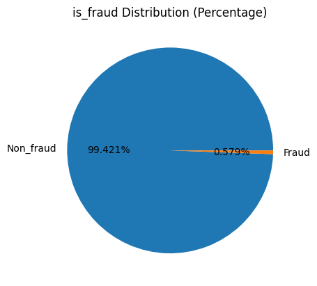

```python
# Set labels
labels = ['Non_fraud', 'Fraud']

# Count of each fraud case
sizes = credit_data.is_fraud.value_counts().values

# plot of the Fraud value counts
fig, ax = plt.subplots()
ax.pie(sizes, labels=labels, autopct='%1.3f%%')
plt.title('is_fraud Distribution (Percentage)')
plt.show()
```

```python
# calculate the correlation
fraud_correlation = credit_data[['amt', 'city_pop', 'trans_year', 'trans_month', 'trans_day', 'trans_hour', 'age']].corr()

print(fraud_correlation)
```

```
                  amt  city_pop  trans_year  trans_month  trans_day  \
amt          1.000000  0.005818    0.000842    -0.001748   0.000629
city_pop     0.005818  1.000000   -0.001673     0.000137   0.000159
trans_year   0.000842 -0.001673    1.000000    -0.464879  -0.045759
trans_month -0.001748  0.000137   -0.464879     1.000000   0.012434
trans_day    0.000629  0.000159   -0.045759     0.012434   1.000000
trans_hour  -0.022811  0.020381   -0.000811    -0.000356  -0.000170
age         -0.009724 -0.091295    0.021605    -0.009882  -0.000620

             trans_hour       age
amt           -0.022811 -0.009724
city_pop       0.020381 -0.091295
trans_year    -0.000811  0.021605
trans_month   -0.000356 -0.009882
trans_day     -0.000170 -0.000620
trans_hour     1.000000 -0.172847
age           -0.172847  1.000000
```

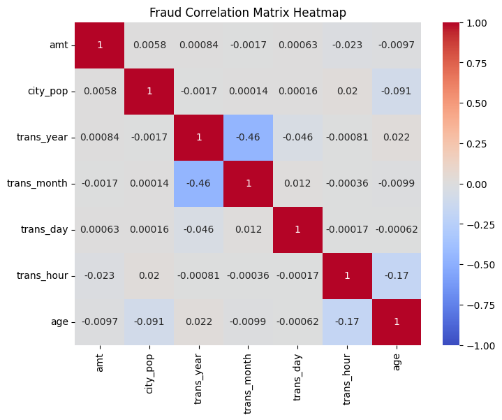

```python
# Create a heatmap of credit card fraud correlation matrix
plt.figure(figsize=(8, 6))
sns.heatmap(fraud_correlation, cmap="coolwarm", annot=True, vmin=-1, vmax=1)
plt.title('Fraud Correlation Matrix Heatmap') # Set title name for heat map
plt.xticks(rotation=90) # Rotate the x-axis labels to avoid overlapping
plt.show()
```

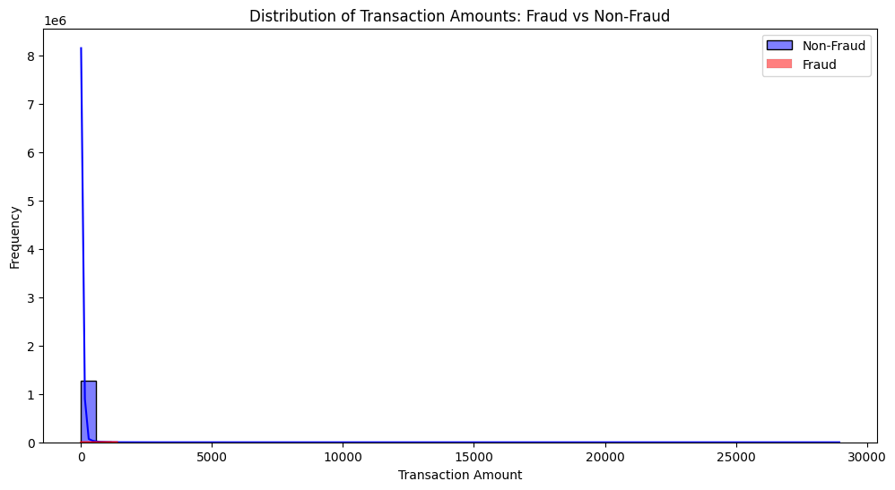

```python
# Analysis: Compare the distribution of transaction amounts between fraud and non-fraud cases
plt.figure(figsize=(12, 6))
sns.histplot(credit_data[credit_data['is_fraud'] == 0]['amt'], bins=50, kde=True, color='blue', label='Non-Fraud')
sns.histplot(credit_data[credit_data['is_fraud'] == 1]['amt'], bins=50, kde=True, color='red', label='Fraud')
plt.legend()
plt.title('Distribution of Transaction Amounts: Fraud vs Non-Fraud')
plt.xlabel('Transaction Amount')
plt.ylabel('Frequency')
plt.show()
```

> The distribution of transaction amounts for fraudulent transactions might show peaks at certain amounts compared to non-fraudulent ones, indicating that frauds often occur at specific transaction amounts.

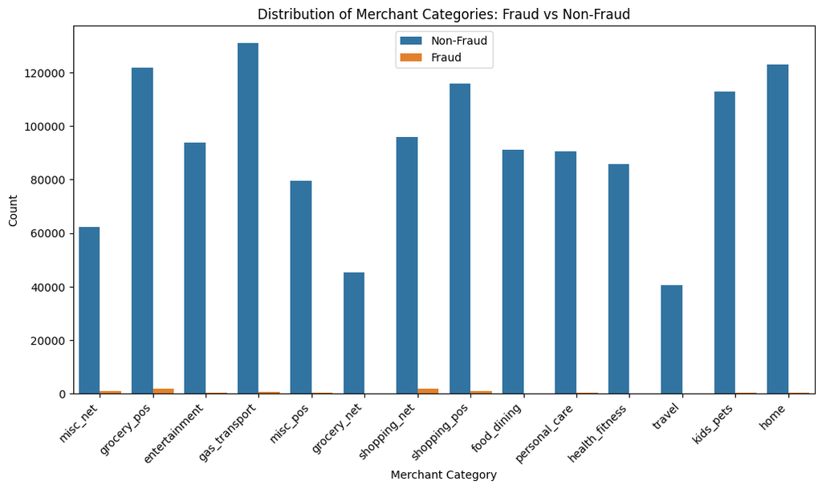

```python
# Analysis: Compare the distribution of merchant categories between fraud and non-fraud cases
plt.figure(figsize=(12, 6))
sns.countplot(x='category', hue='is_fraud', data=credit_data)
plt.title('Distribution of Merchant Categories: Fraud vs Non-Fraud')
plt.xticks(rotation = 45, ha='right') # Rotate the x-axis labels to avoid overlapping
plt.xlabel('Merchant Category')
plt.ylabel('Count')
plt.legend(['Non-Fraud', 'Fraud'])
plt.show()
```

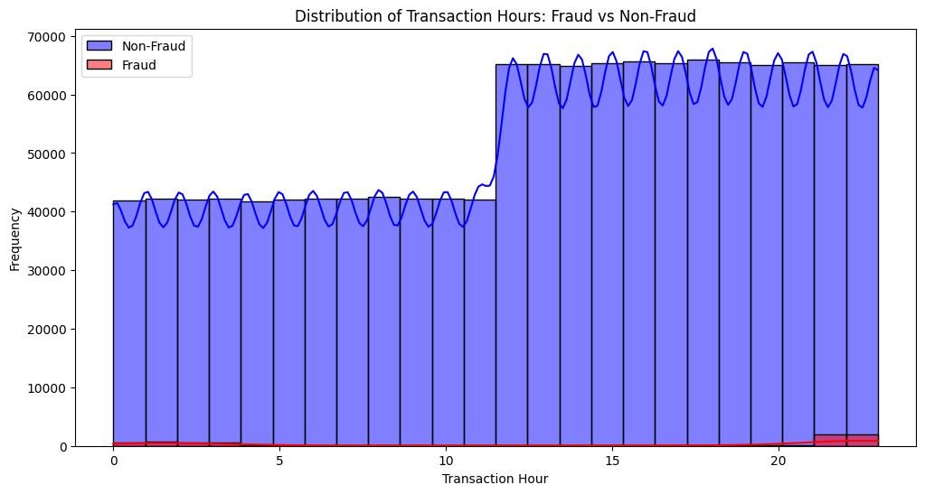

```python
# Analysis: Compare the distribution of transaction time (hour) between fraud and non-fraud cases
plt.figure(figsize=(12, 6))
sns.histplot(credit_data[credit_data['is_fraud'] == 0]['trans_hour'], bins=24, kde=True, color='blue', label='Non-Fraud')
sns.histplot(credit_data[credit_data['is_fraud'] == 1]['trans_hour'], bins=24, kde=True, color='red', label='Fraud')
plt.legend()
plt.title('Distribution of Transaction Hours: Fraud vs Non-Fraud')
plt.xlabel('Transaction Hour')
plt.ylabel('Frequency')
plt.show()
```

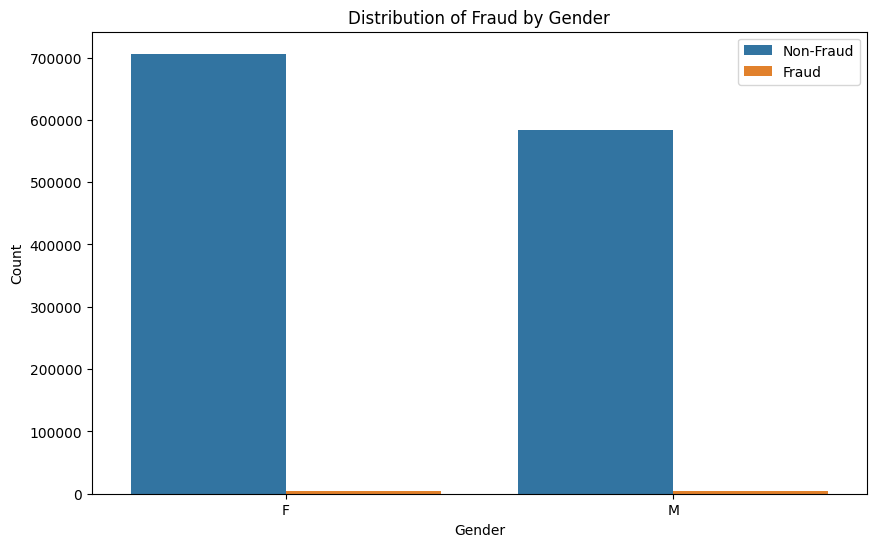

```python
# Visualization of gender vs fraud
plt.figure(figsize=(10, 6))
sns.countplot(x='gender', hue='is_fraud', data=credit_data)
plt.title('Distribution of Fraud by Gender')
plt.xlabel('Gender')
plt.ylabel('Count')
plt.legend(['Non-Fraud', 'Fraud'])
plt.show()
```

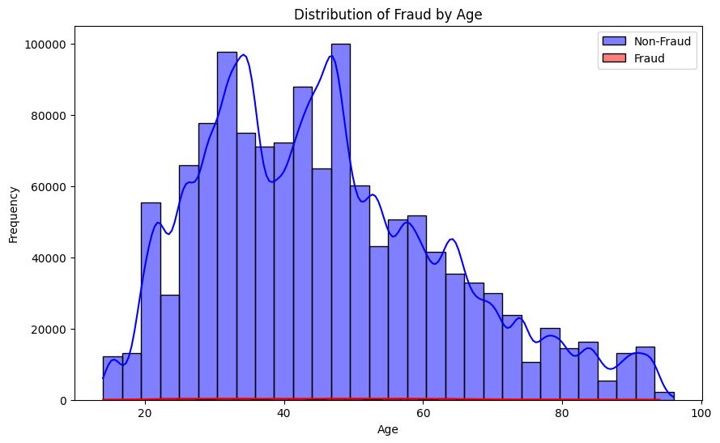

```python
# Visualization of age vs fraud
plt.figure(figsize=(10, 6))
sns.histplot(credit_data[credit_data['is_fraud'] == 0]['age'], bins=30, kde=True, color='blue', label='Non-Fraud')
sns.histplot(credit_data[credit_data['is_fraud'] == 1]['age'], bins=30, kde=True, color='red', label='Fraud')
plt.legend()
plt.title('Distribution of Fraud by Age')
plt.xlabel('Age')
plt.ylabel('Frequency')
plt.show()
```

## 6. Model Training using LightGBM

```python
# Use the fluent API to set the tracking uri and the active experiment
mlflow.set_tracking_uri("http://127.0.0.1:5000/")
```

```python
# Sets the current active experiment to the "Credit_Card_Fraud_Detection" experiment and returns the Experiment metadata
lightgbm_experiment = mlflow.set_experiment("Credit_Card_Fraud_Detection")

# Define a run name for this iteration of training.
# If this is not set, a unique name will be auto-generated for your run.
run_name = "lightgbm_random_search"

# Define an artifact path that the model will be saved to.
artifact_path = "lightbgm_random_search"
```

```python
# Create the random grid of the model hyperparameters
rs_params = {
        'max_depth': (10, 13),
        'num_leaves': (200, 550),
        'n_estimators': (100, 150)
}

# Use the random grid to search for best hyperparameters
# First create the base model to tune
LightGBM_classifier = LGBMClassifier(random_state = 42, device = 'cuda')

# Random search of parameters, using 3 fold cross validation,
# search across 10 different combinations, and use all available cores
LightGBM_random = RandomizedSearchCV(estimator = LightGBM_classifier,
                                     param_distributions = rs_params,
                                     n_iter = 10, scoring='recall',
                                     cv = 3, verbose = 1, n_jobs=-1)


# Fit the random search model
LightGBM_random.fit(X_train_resampled, y_train_resampled);
```

[output not shown]

[output cut: 87 more lines]

[output not shown]

```python
LightGBM_random.best_params_
```

```
{'num_leaves': 550, 'n_estimators': 150, 'max_depth': 10}
```

```python
# Predict on the test set
y_pred = LightGBM_random.predict(X_test)
```

```
Accuracy: 0.9990244278635741


              precision    recall  f1-score   support

           0       1.00      1.00      1.00    257815
           1       0.94      0.89      0.91      1520

    accuracy                           1.00    259335
   macro avg       0.97      0.94      0.96    259335
weighted avg       1.00      1.00      1.00    259335



{'0': {'precision': 0.9993292181708207, 'recall': 0.9996896999786669, 'f1-score': 0.9995094265720164, 'support': 257815.0}, '1': {'precision': 0.9439383321653819, 'recall': 0.8861842105263158, 'f1-score': 0.9141499830335935, 'support': 1520.0}, 'accuracy': 0.9990244278635741, 'macro avg': {'precisio…
```

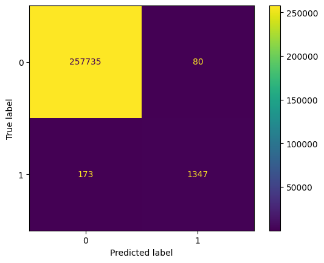

```python
# Calculate accurcy, f1-score, recall, confusion matrix
accuracy = accuracy_score(y_test, y_pred)
print(f"Accuracy: {accuracy}")
print("\n")

class_report = classification_report(y_test, y_pred)
print(class_report)
print("\n")

class_report_dict = classification_report(y_test, y_pred, output_dict=True)
print(class_report_dict)
print("\n")

conf_matrix = confusion_matrix(y_test, y_pred)
ConfusionMatrixDisplay(conf_matrix).plot()

# Assemble the metrics we're going to write into a collection
metrics = {'accuracy': accuracy,
           'f1_score_class_0': class_report_dict['0']['f1-score'],
           'f1_score_class_1': class_report_dict['1']['f1-score'],
           'recall_class_0': class_report_dict['0']['recall'],
           'recall_class_1': class_report_dict['1']['recall'],
          }
```

```python
# Initiate the MLflow run context
with mlflow.start_run(run_name=run_name) as run:

    # Log the BEST parameters found by RandomizedSearchCV
    mlflow.log_params(LightGBM_random.best_params_)

    # Log the error metrics
    mlflow.log_metrics(metrics)

    # Log an instance of the trained model for later use
    mlflow.sklearn.log_model(sk_model = LightGBM_random, input_example = X_train_resampled, name = artifact_path)
```

```
🏃 View run lightgbm_random_search at: http://127.0.0.1:5000/#/experiments/473204961532434743/runs/1a02c0dc5e1d4b33964c67ba15f763bc
🧪 View experiment at: http://127.0.0.1:5000/#/experiments/473204961532434743
```

## 7. LightGBM Feature Importance and SHAP Values

```python
best_lgbm = LightGBM_random.best_estimator_
print(best_lgbm)
print("\n")

feature_names = X_train_resampled.columns.tolist()

# Get feature importance from the best estimator
importance_scores = best_lgbm.feature_importances_
print(importance_scores)
print("\n")

# Create a DataFrame for easy viewing and sorting
feature_importance_df = pd.DataFrame({
    'Feature': feature_names,
    'Importance': importance_scores
})

# Sort by importance
feature_importance_df = feature_importance_df.sort_values(by='Importance', ascending=False)

print(feature_importance_df)
```

```
LGBMClassifier(device='cuda', max_depth=10, n_estimators=150, num_leaves=550,
               random_state=42)


[ 5639  4856  1635 11715  7636 11322  1319  6305  9866  2992 12865  6200
     0]


           Feature  Importance
10      trans_hour       12865
3             city       11715
5         city_pop       11322
8        trans_day        9866
4            state        7636
7      trans_month        6305
11       age_group        6200
0         category        5639
1              amt        4856
9   trans_day_name        2992
2           gender        1635
6       trans_year        1319
12    amount_group           0
```

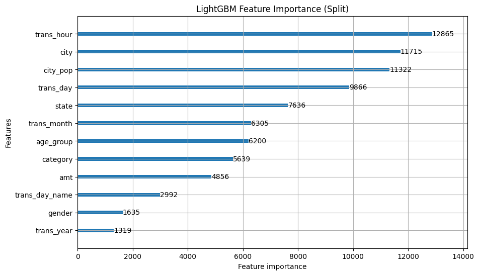

```python
lgb.plot_importance(
    best_lgbm,
    importance_type='split',
    figsize=(10, 6),
    title='LightGBM Feature Importance (Split)'
)

plt.show()
```

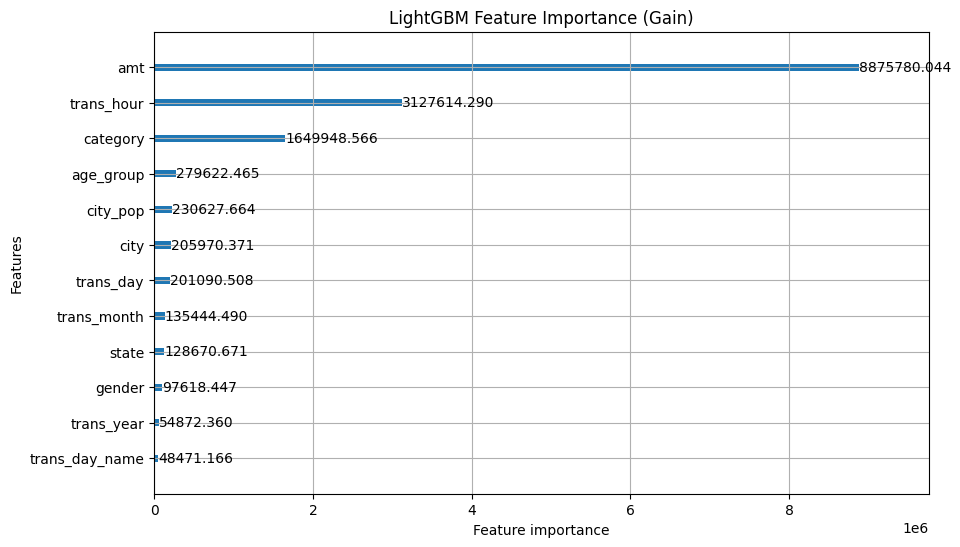

```python
lgb.plot_importance(
    best_lgbm,
    importance_type='gain',
    figsize=(10, 6),
    title='LightGBM Feature Importance (Gain)'
)

plt.show()
```

```python
# Initialize SHAP explainer for LightGBM
explainer = shap.explainers.GPUTree(best_lgbm, X_train_resampled)
shap_values = explainer(X_train_resampled)
```

[output not shown]

##### It took more than an hour to calculate the SHAP values eventhough I used GPU for calculation and it did not even complete due to error.

> Upon research, I found out that the error was likely due to a minor numerical discrepancy between the GPU model prediction and the GPUTree explanation.

##### So, I will be using 100k samples from the training set (SMOTE applied) to calculate the SHAP values.

```python
sample_size = 100000

# Get random indices
sample_indices = np.random.choice(X_train_resampled.shape[0], size=sample_size, replace=False)

# Create the sampled data
X_sample = X_train_resampled.iloc[sample_indices]

# Using the smaller sample for the explainer
explainer = shap.explainers.GPUTree(best_lgbm, X_sample)
shap_values = explainer(X_sample)
```

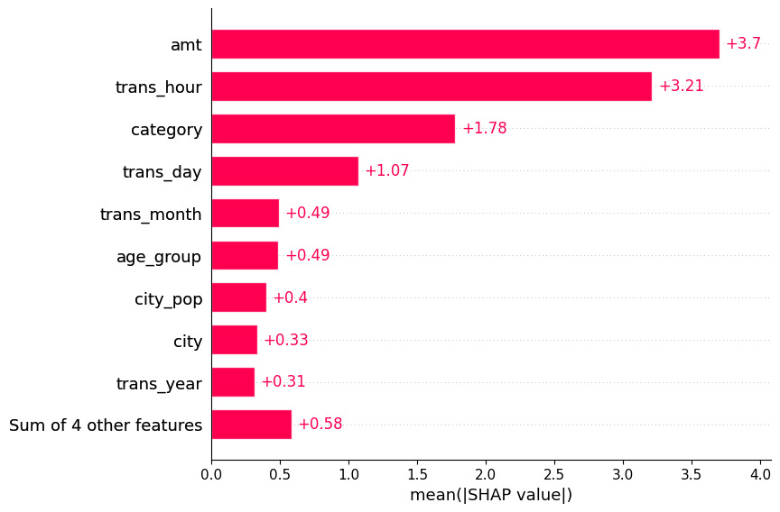

```python
# Bar plot
shap.plots.bar(shap_values)
```

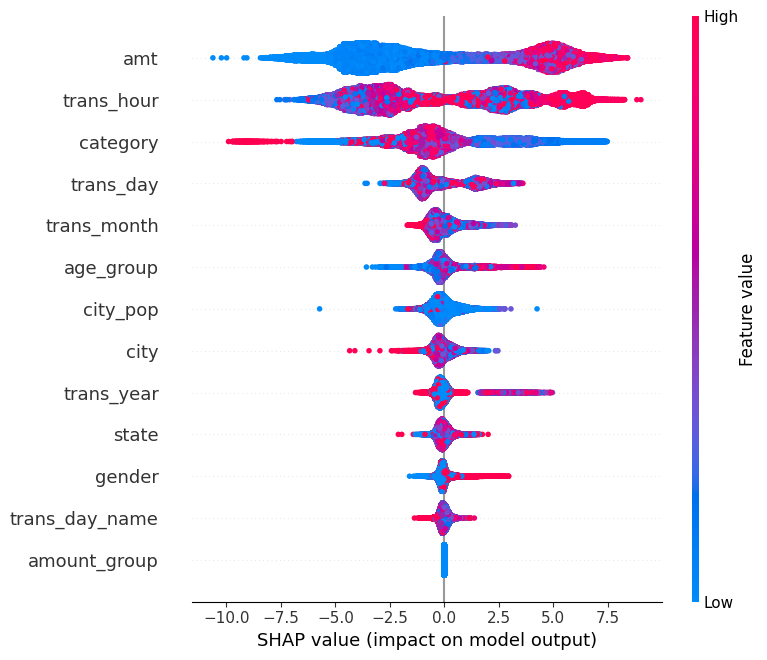

```python
# Summary plot
shap.summary_plot(shap_values, X_sample)
```

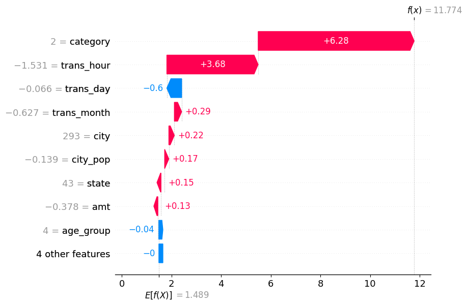

```python
# Plot a single instance
shap.plots.waterfall(shap_values[0])
```

## 8. Model Training using XGBoost

```python
# Use the fluent API to set the tracking uri and the active experiment
mlflow.set_tracking_uri("http://127.0.0.1:5000/")
```

```python
# Sets the current active experiment to the "Credit_Card_Fraud_Detection" experiment and returns the Experiment metadata
xgboost_experiment = mlflow.set_experiment("Credit_Card_Fraud_Detection")

# Define a run name for this iteration of training.
# If this is not set, a unique name will be auto-generated for your run.
run_name = "xgboost_grid_search"

# Define an artifact path that the model will be saved to.
artifact_path = "xgboost_grid_search"
```

```python
# Create the grid of the model hyperparameters
gs_params = {
        'n_estimators': [100, 300],
        'max_depth': [10, 30],
        'booster': ['gbtree']
}

# Use the grid to search for best hyperparameters
# First create the base model to tune
XGBoost_classifier = XGBClassifier(random_state = 42, device = 'cuda')

# Grid search of parameters, use all available cores
XGBoost_grid = GridSearchCV(estimator = XGBoost_classifier,
                                     param_grid = gs_params,
                                     scoring='recall', verbose = 1, n_jobs=-1)


# Fit the grid search model
XGBoost_grid.fit(X_train_resampled, y_train_resampled);
```

```
Fitting 5 folds for each of 4 candidates, totalling 20 fits
```

```python
XGBoost_grid.best_params_
```

```
{'booster': 'gbtree', 'max_depth': 10, 'n_estimators': 300}
```

```python
# Predict on the test set
y_pred = XGBoost_grid.predict(X_test)
```

```
Accuracy: 0.999190236566603


              precision    recall  f1-score   support

           0       1.00      1.00      1.00    257815
           1       0.95      0.91      0.93      1520

    accuracy                           1.00    259335
   macro avg       0.97      0.96      0.96    259335
weighted avg       1.00      1.00      1.00    259335



{'0': {'precision': 0.9994803643654047, 'recall': 0.9997052149797335, 'f1-score': 0.9995927770279704, 'support': 257815.0}, '1': {'precision': 0.948016415868673, 'recall': 0.9118421052631579, 'f1-score': 0.9295774647887324, 'support': 1520.0}, 'accuracy': 0.999190236566603, 'macro avg': {'precision'…
```

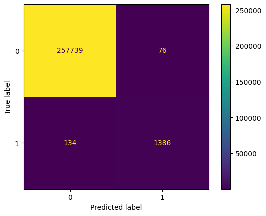

```python
# Calculate accurcy, f1-score, recall, confusion matrix
accuracy = accuracy_score(y_test, y_pred)
print(f"Accuracy: {accuracy}")
print("\n")

class_report = classification_report(y_test, y_pred)
print(class_report)
print("\n")

class_report_dict = classification_report(y_test, y_pred, output_dict=True)
print(class_report_dict)
print("\n")

conf_matrix = confusion_matrix(y_test, y_pred)
ConfusionMatrixDisplay(conf_matrix).plot()

# Assemble the metrics we're going to write into a collection
metrics = {'accuracy': accuracy,
           'f1_score_class_0': class_report_dict['0']['f1-score'],
           'f1_score_class_1': class_report_dict['1']['f1-score'],
           'recall_class_0': class_report_dict['0']['recall'],
           'recall_class_1': class_report_dict['1']['recall'],
          }
```

```python
# Initiate the MLflow run context
with mlflow.start_run(run_name=run_name) as run:

    # Log the BEST parameters found by GridSearchCV
    mlflow.log_params(XGBoost_grid.best_params_)

    # Log the error metrics
    mlflow.log_metrics(metrics)

    # Log an instance of the trained model for later use
    mlflow.sklearn.log_model(sk_model = XGBoost_grid, input_example = X_train_resampled, name = artifact_path)
```

```
🏃 View run xgboost_grid_search at: http://127.0.0.1:5000/#/experiments/473204961532434743/runs/d81121cf45724603b4c63850bc3aa0aa
🧪 View experiment at: http://127.0.0.1:5000/#/experiments/473204961532434743
```

## 9. XGBoost Feature Importance and SHAP Values

```
XGBClassifier(base_score=None, booster='gbtree', callbacks=None,
              colsample_bylevel=None, colsample_bynode=None,
              colsample_bytree=None, device='cuda', early_stopping_rounds=None,
              enable_categorical=False, eval_metric=None, feature_types=None,
              feature_weights=None, gamma=None, grow_policy=None,
              importance_type=None, interaction_constraints=None,
              learning_rate=None, max_bin=None, max_cat_threshold=None,
              max_cat_to_onehot=None, max_delta_step=None, max_depth=10,
              max_leaves=None, min_child_weight=None, missing=nan,
              monotone_constraints=None, multi_strategy=None, n_estimators=300,
              n_jobs=None, num_parallel_tree=None, ...)


[0.13467336 0.5294824  0.03086178 0.01180512 0.01137614 0.01276199
 0.03279286 0.01635996 0.01639966 0.00991889 0.16947427 0.02409353
 0.        ]


           Feature  Importance
12    amount_group    0.000000
9   trans_day_name    0.009919
4            state    0.011376
3             city    0.011805
5         city_pop    0.012762
7      trans_month    0.016360
8        trans_day    0.016400
11       age_group    0.024094
2           gender    0.030862
6       trans_year    0.032793
0         category    0.134673
10      trans_hour    0.169474
1              amt    0.529482
```

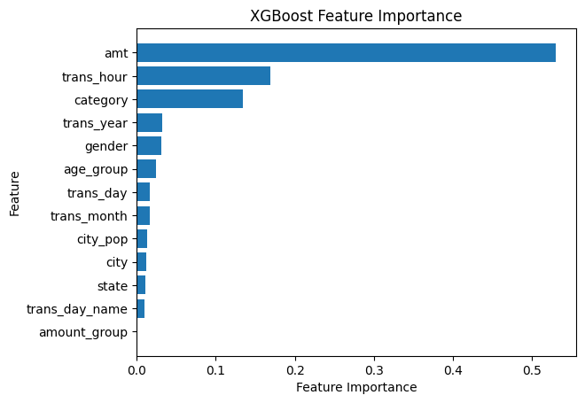

```python
best_xgboost = XGBoost_grid.best_estimator_
print(best_xgboost)
print("\n")

feature_names = X_train_resampled.columns.tolist()

# Get feature importance from the best estimator
importance_scores = best_xgboost.feature_importances_
print(importance_scores)
print("\n")

# Create a DataFrame for easy viewing and sorting
feature_importance_df = pd.DataFrame({
    'Feature': feature_names,
    'Importance': importance_scores
})

# Sort by importance
feature_importance_df = feature_importance_df.sort_values(by='Importance')

print(feature_importance_df)
print("\n")


# Horizontal bar plot
plt.barh(
    feature_importance_df['Feature'],
    feature_importance_df['Importance']
)

plt.xlabel('Feature Importance')
plt.ylabel('Feature')
plt.title('XGBoost Feature Importance')
plt.show()
```

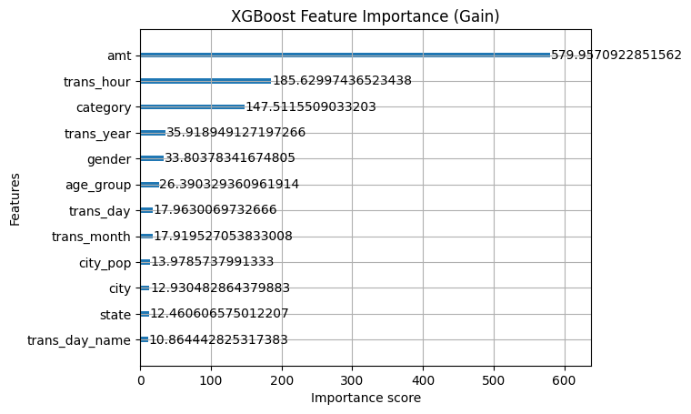

```python
xgb.plot_importance(
    best_xgboost,
    importance_type='gain',
    title='XGBoost Feature Importance (Gain)'
)

plt.show()
```

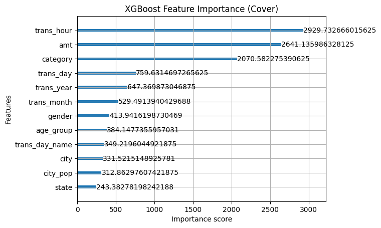

```python
xgb.plot_importance(
    best_xgboost,
    importance_type='cover',
    title='XGBoost Feature Importance (Cover)'
)

plt.show()
```

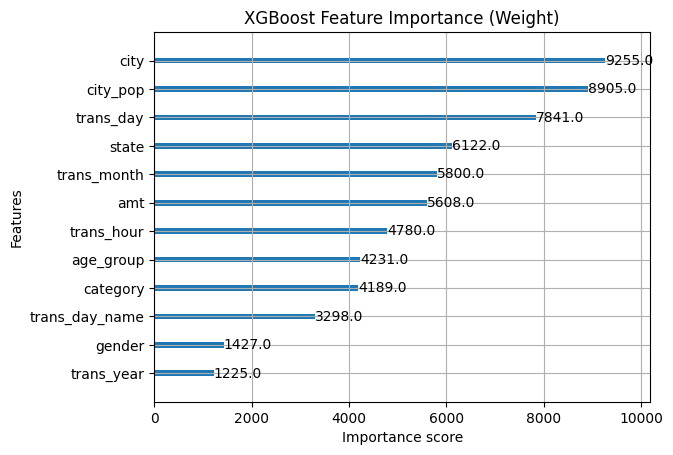

```python
xgb.plot_importance(
    best_xgboost,
    importance_type='weight',
    title='XGBoost Feature Importance (Weight)'
)

plt.show()
```

```python
# Initialize SHAP explainer for XGBoost
explainer = shap.explainers.GPUTree(best_xgboost, X_train_resampled)
shap_values = explainer(X_train_resampled)
```

#### Used the entire training set to calculate SHAP values unlike the LightGBM where I used a small subset of the training set.

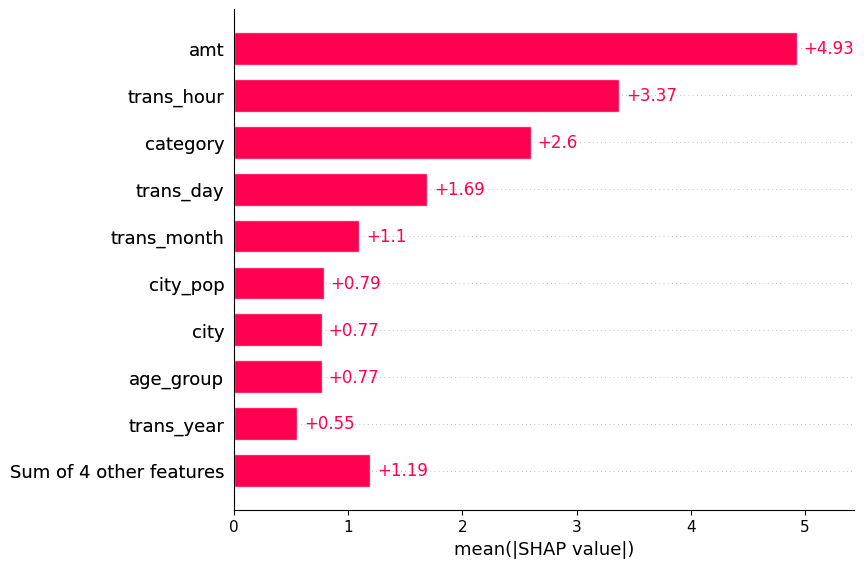

```python
# Bar plot
shap.plots.bar(shap_values)
```

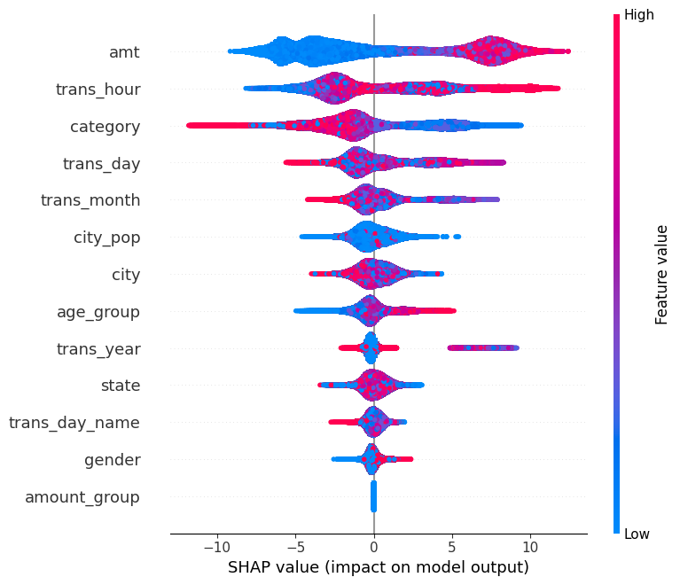

```python
# Summary plot
shap.summary_plot(shap_values, X_train_resampled)
```

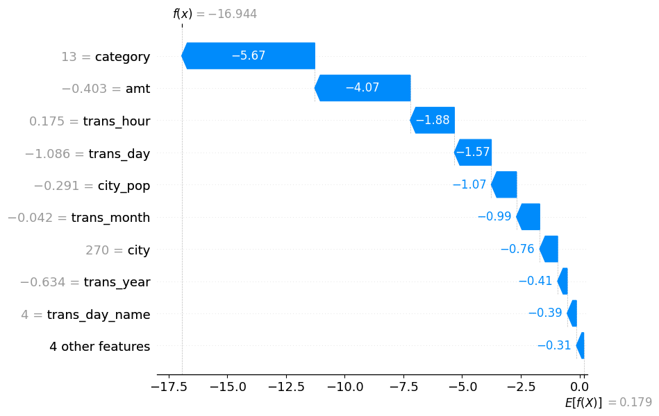

```python
# Plot a single instance
shap.plots.waterfall(shap_values[0])
```

## 10. Model Training using RandomForest

```python
# Use the fluent API to set the tracking uri and the active experiment
mlflow.set_tracking_uri("http://127.0.0.1:5000/")
```

```python
# Sets the current active experiment to the "Credit_Card_Fraud_Detection" experiment and returns the Experiment metadata
randomforest_experiment = mlflow.set_experiment("Credit_Card_Fraud_Detection")

# Define a run name for this iteration of training.
# If this is not set, a unique name will be auto-generated for your run.
run_name = "randomforest_grid_search"

# Define an artifact path that the model will be saved to.
artifact_path = "randomforest_grid_search"
```

##### Since, I will be training RandomForest using CPU only unlike LightGBM and XGBoost wehere I used GPU, I am limiting the training set to 100k only.

##### I installed cuML successfully but had errors while importing so I can't use cuML version of RandomForest, so the training set limitation.

```python
# Limit training set to 100k samples
X_train_subset, _, y__train_subset, _ = train_test_split(
    X_train_resampled,
    y_train_resampled,
    train_size=100000,
    stratify=y_train_resampled,
    random_state=42
)
```

```python
# Create the grid of the model hyperparameters
rf_params = {
        'min_samples_leaf': [5, 8, 10],
        'min_samples_split': [8, 10, 12],
        'n_estimators': [100, 200, 300]
}

# Use the grid to search for best hyperparameters
# First create the base model to tune
Rf_classifier = RandomForestClassifier(random_state = 42)

# Grid search of parameters, use all available cores
Rf_grid = GridSearchCV(estimator = Rf_classifier, param_grid = rf_params,
                                     scoring='recall', verbose = 1, n_jobs=-1)


# Fit the grid search model
Rf_grid.fit(X_train_subset, y__train_subset);
```

```
Fitting 5 folds for each of 27 candidates, totalling 135 fits
```

```python
Rf_grid.best_params_
```

```
{'min_samples_leaf': 5, 'min_samples_split': 8, 'n_estimators': 200}
```

```python
# Predict on the test set
y_pred = Rf_grid.predict(X_test)
```

```
Accuracy: 0.9790117030096208


              precision    recall  f1-score   support

           0       1.00      0.98      0.99    257815
           1       0.20      0.89      0.33      1520

    accuracy                           0.98    259335
   macro avg       0.60      0.93      0.66    259335
weighted avg       0.99      0.98      0.99    259335



{'0': {'precision': 0.9993154425090417, 'recall': 0.9795589860946803, 'f1-score': 0.9893385931957386, 'support': 257815.0}, '1': {'precision': 0.20356657095360436, 'recall': 0.8861842105263158, 'f1-score': 0.33108025070664865, 'support': 1520.0}, 'accuracy': 0.9790117030096208, 'macro avg': {'precis…
```

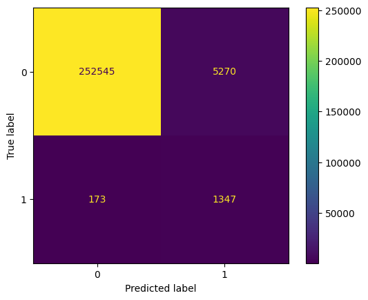

```python
# Calculate accurcy, f1-score, recall, confusion matrix
accuracy = accuracy_score(y_test, y_pred)
print(f"Accuracy: {accuracy}")
print("\n")

class_report = classification_report(y_test, y_pred)
print(class_report)
print("\n")

class_report_dict = classification_report(y_test, y_pred, output_dict=True)
print(class_report_dict)
print("\n")

conf_matrix = confusion_matrix(y_test, y_pred)
ConfusionMatrixDisplay(conf_matrix).plot()

# Assemble the metrics we're going to write into a collection
metrics = {'accuracy': accuracy,
           'f1_score_class_0': class_report_dict['0']['f1-score'],
           'f1_score_class_1': class_report_dict['1']['f1-score'],
           'recall_class_0': class_report_dict['0']['recall'],
           'recall_class_1': class_report_dict['1']['recall'],
          }
```

```python
# Initiate the MLflow run context
with mlflow.start_run(run_name=run_name) as run:

    # Log the BEST parameters found by GridSearchCV
    mlflow.log_params(Rf_grid.best_params_)

    # Log the error metrics
    mlflow.log_metrics(metrics)

    # Log an instance of the trained model for later use
    mlflow.sklearn.log_model(sk_model = Rf_grid, input_example = X_train_subset, name = artifact_path)
```

```
🏃 View run randomforest_grid_search at: http://127.0.0.1:5000/#/experiments/473204961532434743/runs/274eac1e7d17467a9e31e00eaa96ef89
🧪 View experiment at: http://127.0.0.1:5000/#/experiments/473204961532434743
```

## 11. RandomForest Feature Importance and SHAP Values

```
RandomForestClassifier(min_samples_leaf=5, min_samples_split=8,
                       n_estimators=200, random_state=42)


[8.53627330e-02 5.89374581e-01 7.08410954e-03 2.44569425e-02
 1.78626511e-02 2.60995989e-02 1.26742021e-02 2.44385810e-02
 2.39762411e-02 1.16811798e-02 1.60212659e-01 1.67725391e-02
 3.98141815e-06]


           Feature  Importance
12    amount_group    0.000004
2           gender    0.007084
9   trans_day_name    0.011681
6       trans_year    0.012674
11       age_group    0.016773
4            state    0.017863
8        trans_day    0.023976
7      trans_month    0.024439
3             city    0.024457
5         city_pop    0.026100
0         category    0.085363
10      trans_hour    0.160213
1              amt    0.589375
```

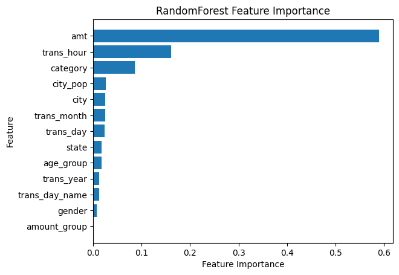

```python
best_randomforest = Rf_grid.best_estimator_
print(best_randomforest)
print("\n")

feature_names = X_train_resampled.columns.tolist()

# Get feature importance from the best estimator
importance_scores = best_randomforest.feature_importances_
print(importance_scores)
print("\n")

# Create a DataFrame for easy viewing and sorting
feature_importance_df = pd.DataFrame({
    'Feature': feature_names,
    'Importance': importance_scores
})

# Sort by importance
feature_importance_df = feature_importance_df.sort_values(by='Importance')

print(feature_importance_df)
print("\n")


# Horizontal bar plot
plt.barh(
    feature_importance_df['Feature'],
    feature_importance_df['Importance']
)

plt.xlabel('Feature Importance')
plt.ylabel('Feature')
plt.title('RandomForest Feature Importance')
plt.show()
```

```python
# Initialize SHAP explainer for RandomForest
explainer = shap.explainers.GPUTree(best_randomforest, X_train_subset)
shap_values = explainer(X_train_subset)
```

[figure not shown]

```python
# Summary plot
shap.summary_plot(shap_values, X_train_subset)
```